# Chapter 5 - Working with large datasets

Edson Raul Cepeda Marquez

The concept of *Big Data* refers to very large datasets. Dealing with Big Data is also part of data science. The science of what you can do with data in a given amount of time, or a given amount of space, is called *complexity theory*.

### Subsample your data before you analize the full dataset.

You very rarely need to analyze a complete dataset to get a least an idea of how the data behaves. You should explore a smaller sample of your data. Here it is important that you pick a random sample. If you have a large dataset, and your analysis is being slowed down because of ti, don’t be afraid to pick a random subset and analyze that.

You can use the `dplyr` functions `sample_n()` and `sample_frac()` to sample from a data frame. Use `sample_n()` to get fixed numbers of rows and `sample_frac()` to get a fraction of the data:

```r
library(dplyr)
library(magrittr)

iris %>% sample_n(size = 5)
```

```
##   Sepal.Length Sepal.Width Petal.Length
## 1          4.4         3.0          1.3
## 2          5.8         2.8          5.1
## 3          5.7         2.8          4.1
## 4          5.8         2.7          5.1
## 5          4.9         3.1          1.5
##   Petal.Width    Species
## 1         0.2     setosa
## 2         2.4  virginica
## 3         1.3 versicolor
## 4         1.9  virginica
## 5         0.1     setosa
```

```r
iris %>% sample_frac(size = 0.02)
```

```
##   Sepal.Length Sepal.Width Petal.Length
## 1          6.3         2.5          5.0
## 2          5.0         3.6          1.4
## 3          7.2         3.0          5.8
##   Petal.Width   Species
## 1         1.9 virginica
## 2         0.2    setosa
## 3         1.6 virginica
```

You need your data in a form `dplyr` can manipulate, and if the data is too large even to load into R, then you cannot have it in a data frame to sample from.

Luckily, `dplyr` has support for using data stored on disk rather than in RAM, in various backend formats. It is, possible to connect a database to `dplyr` and sample from a large dataset this way.

### Running Out of Memory During Analysis

You can examine memory usage and memory changes using the `pryr` package:

```r
library(pryr)
mem_change(x <- rnorm(10000))
```

```
## -12.3 kB
```

Modifying this vector:

```r
mem_change(x[1] <- 0)
```

```
## 528 B
```

If we assing vector to another variable, we do not use twice as memory:

```r
mem_change(y <- x)
```

```
## -79.5 kB
```

But then if we modify one vector, we will have to make a copy so the other vector remains the same:

```r
mem_change(x[1] <- 0)
```

```
## 80.6 kB
```

**This is one reason for using pipelines rather than assigning to many variables during analysis**.

You can remove stored data using `rm()` function to free up memory.

### Too large to plot

There are two problems when making scatterplots with a lot of data.

1. If you create files from scatterplots, you will create a plot that contains every single individual point.
2. With too manypoints, a scatterplot is just not informative.

For example:

```r
d <- data.frame(x = rnorm(10000), y = rnorm(10000))
```

If the plot is saved as raste graphics instead of PDF, the file will not be too large to watch or print.

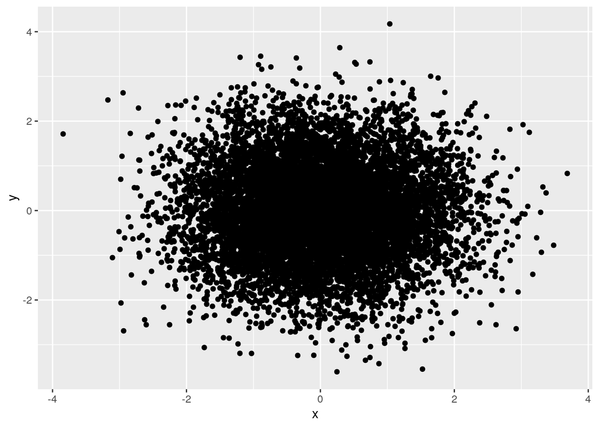

```r
library(ggplot2)
d %>% ggplot(aes(x = x, y = y)) +
    geom_point()
```

The solution is to represent points in a way such that they still visible even when there are many overlapping points. If the points are overlapping because they actually have the same x- or y-coordinates, you can jitter them.

Another solution to the same problem is plotting the points with alpha levels so each point is partly transparent.

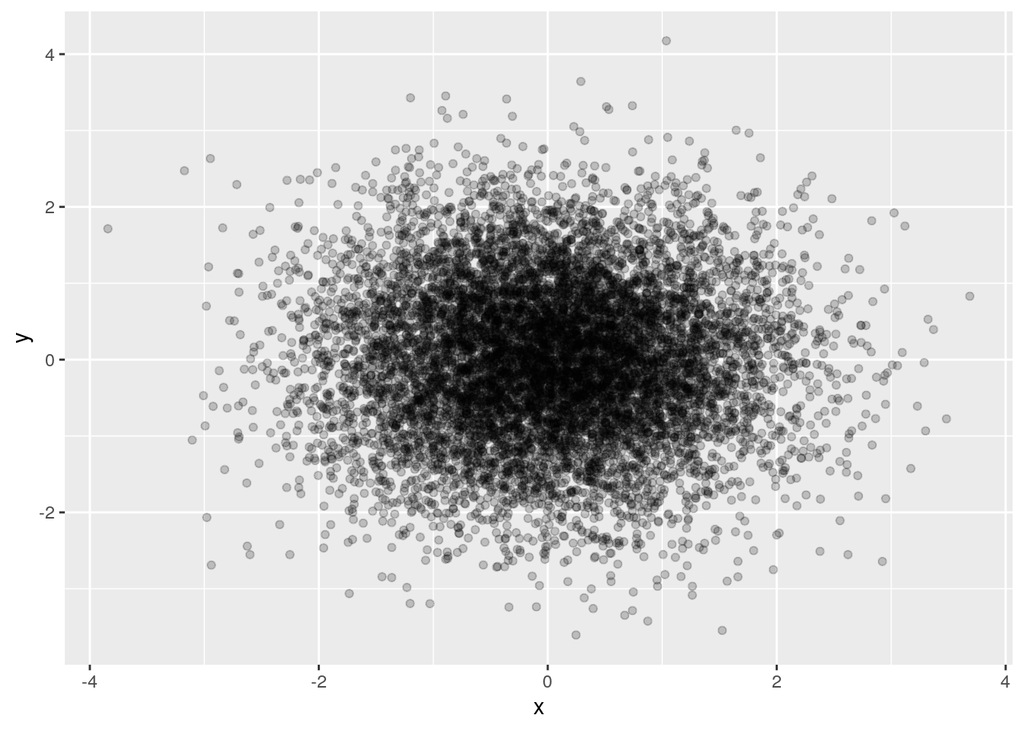

```r
d %>% ggplot(aes(x = x, y = y)) +
    geom_point(alpha = 0.2)
```

This doesn’t solve the problem of the file size. A scatterplot with transparency is just a way of showing 2D density, though, and you cando that directly using the `geom_density_2d()` function:

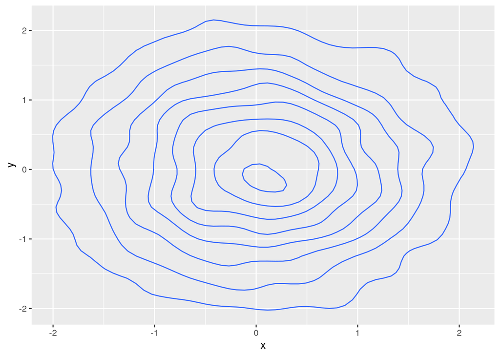

```r
d %>% ggplot(aes(x = x, y = y)) +
    geom_density_2d()
```

An alternative way of showing 2D density is using a so-called hex-plot. This is the 2D equivalent of the histogram. The 2D plane is split into hexagonal bins, and the plot shows the count of points falling into each bin.

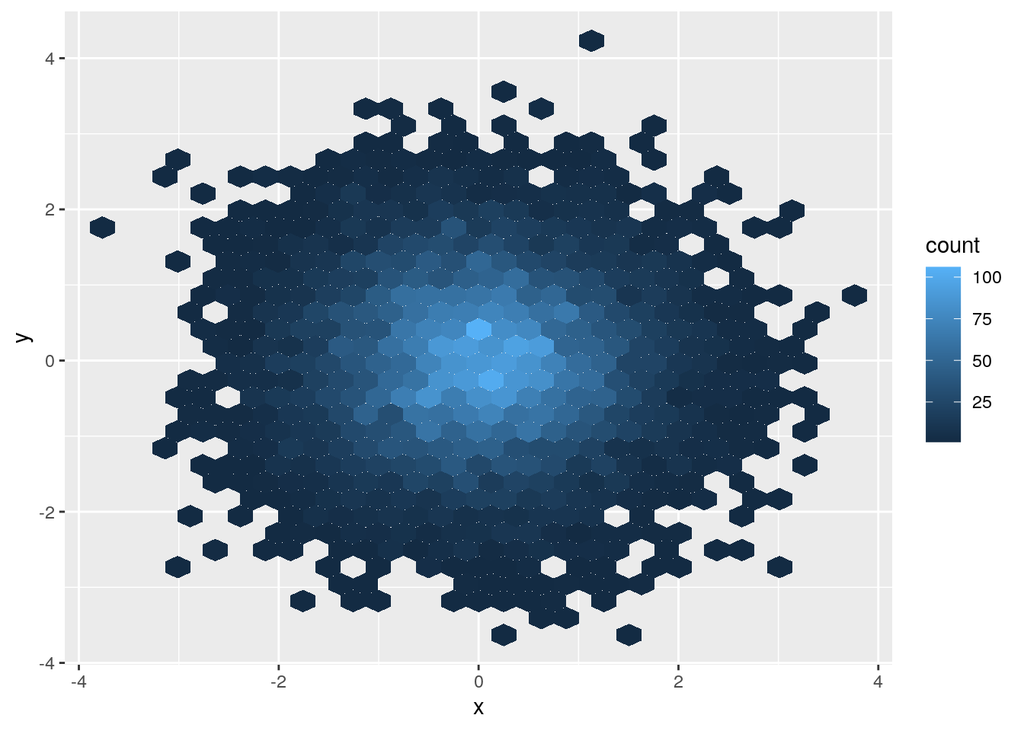

```r
d %>% ggplot(aes(x = x, y = y)) +
    geom_hex()
```

The colors used by `geom_hex()` are the fill colors, so you can change them using `scale_fill` functions.

You can also combine hex and 2D density plots to get both the bins and contours displayed:

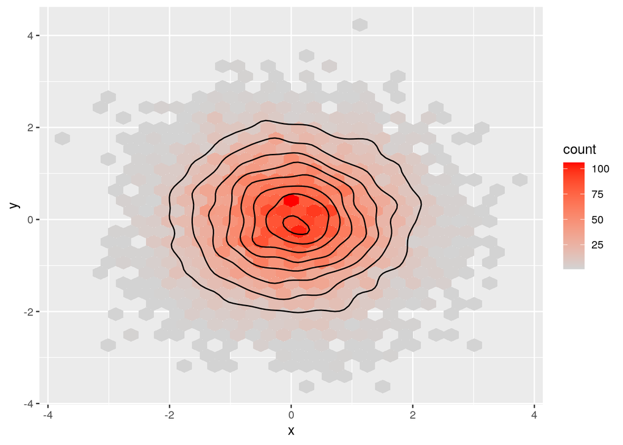

```r
d %>% ggplot(aes(x = x, y = y)) +
    geom_hex() +
    scale_fill_gradient(low = "lightgray", high = "red") +
    geom_density_2d(color = "black")
```

### Too slow to analyse

When subsampling large datasets is not an option some specialized packages are needed to handle lots of data in a linear time. One package that both provides a memory efficient linear model fitting (it avoids creating a model matrix that would have rows for each data point and solving equations for that) and functionality for updating the model in batches is the `biglm` package:

```r
library(biglm)
```

You can use it for linear regression using the `biglm()` function instead of `lm()`.

If you are using a data frame format that stores the data on disk and has support for `biglm`, the package will split the data into chunks that it can load into memory and analyse. If you don’t have a package that handles this automatically, you can split the data into chunks youself.

As an example we consider the `cars` dataset and try to fit a linear model of stopping distance as a function of speed, and we do it in batches of 10 points. Defining the slice indices requires some arithmetic but for that we use the `slice()` function of `dplyr` instead.

We can create a linear model from from the first slice and then update using the following code:

```r
slice_size <- 10
n <- nrow(cars)
slice <- cars %>% slice(1:slice_size)
model <- biglm(dist ~ speed, data = slice)
for(i in 1:(n/slice_size-1)) {
    slice <- cars %>% slice((i*slice_size+1):((i+1)*slice_size))
    model <- update(model, moredata = slice)
}
model
```

```
## Large data regression model: biglm(dist ~ speed, data = slice)
## Sample size =  50
```

### Too large to load

R wants to keep the datra it works on in memory. R uses 32-bit integers for indeices, both positive and negative, so you are limited to indexing around 2 billion data points.

A package to deal with this is the `ff` package. It works with the kind of tables we have used so far but uses memory mapped files to represent the data and load data chunks into memory as needed.

```r
library(ff)
```

It represents data frames as objects of the class `ffdf()`. THis behave just like data frame if you use them as sucj and tou can translate a data frame into a `ffdf` object using the `as.ffdf()` function.

Converting cars data into an `ffdf` object:

```r
ffcars <- as.ffdf(cars)
summary(ffcars)
```

```
##       Length Class     Mode
## speed 50     ff_vector list
## dist  50     ff_vector list
```

You can also read from files, for example with the `read.csv.ffdf()`.

The `ff` package includes various functions for computing summary statistics efficiently from the memory mapped flat files. This sometimes doesn’t work if the data is too large to fit and load even in a flat file.

So, to deal with data that you cannot load into memory you will have to analyse it in batches. This means that you need special function for analysing data, and quite often you need to implement analysis algorithms yourself.

The `bigml` package implement the linear models as generic functions. If you just give them an `ffdf` object, they will treat it as a `data.frame` object and not exploit that the data can be fitted in chunks. The `ffbase` package deals with this by implementing a special `bigglm()` function that works on `ffdf` object. To fit a linear model (or generalized linear), just load the package:

```r
# library(ffbase)
# x <- as.ffdf(cars)
# model <- bigglm.ffdf(dist ~ speed, data = x, chunksize = 10)
# summary(model)
```